# Chicago City Council: local ideal points, 2003–2026

Two decades of council voting

Author

Boris Shor

Updated

October 18, 2026

Chicago’s contested council votes reveal a broad divide between progressive members and more moderate or conservative coalitions within an overwhelmingly Democratic political world. This analysis places **132 councillors serving from 2003 through 2026** on a pooled voting spectrum. The recent progressive caucuses cluster toward one end, while ward presidential results provide an external check on the pattern. The historical coverage makes it possible to see successive elected councils on the same city-specific scale.

**132 members**  
Across successive councils

**6 council terms**  
Plus the outgoing 2003 council

**693 roll calls**  
Contested council decisions

**32,980 votes**  
Recorded yeas and nays

## Dataset and coverage

The analysis uses **published roll-call votes** in the Chicago City Clerk’s *Journal of the Proceedings*, assembled in the *MyTown* local-government corpus (2026, CC BY 4.0, [DOI 10.57967/hf/9676](https://doi.org/10.57967/hf/9676)). The journal coverage runs from January 16, 2003 through June 17, 2026; the earliest contested event retained here is February 5, 2003. The data cover the elected City Council, not committee votes.

The source contains **26,215 recorded roll calls**, of which 727 contain both yeas and nays. After resolving member identities and retaining members with at least four usable contested votes, 693 roll calls enter the model. A single member in the minority is enough. This keeps genuine disagreements in a fifty-seat council without asking unanimous votes to distinguish members. Unrecorded responses are missing, not nays or presumed absences.

| Council period | Members observed | Contested roll calls | Yeas and nays |
| --- | --- | --- | --- |
| 2003 outgoing council | 49 | 7 | 314 |
| 2003–2007 | 53 | 54 | 2,503 |
| 2007–2011 | 56 | 58 | 2,683 |
| 2011–2015 | 52 | 86 | 4,127 |
| 2015–2019 | 52 | 152 | 7,268 |
| 2019–2023 | 54 | 128 | 6,143 |
| 2023–2027 | 52 | 208 | 9,942 |

Council periods follow election turnover, not arbitrary time bins. Member counts can exceed 50 because of midterm replacements. The outgoing 2003 council is only a short fragment of its term; it is shown separately. Each member has one pooled position, displayed in every council in which their votes are observed.

## The current council

An **ideal point** summarizes how similarly members vote on contested decisions. Nearby members tend to vote alike; distant members tend to take opposing sides. These positions are relative to Chicago, not scores on an absolute national ideological scale.

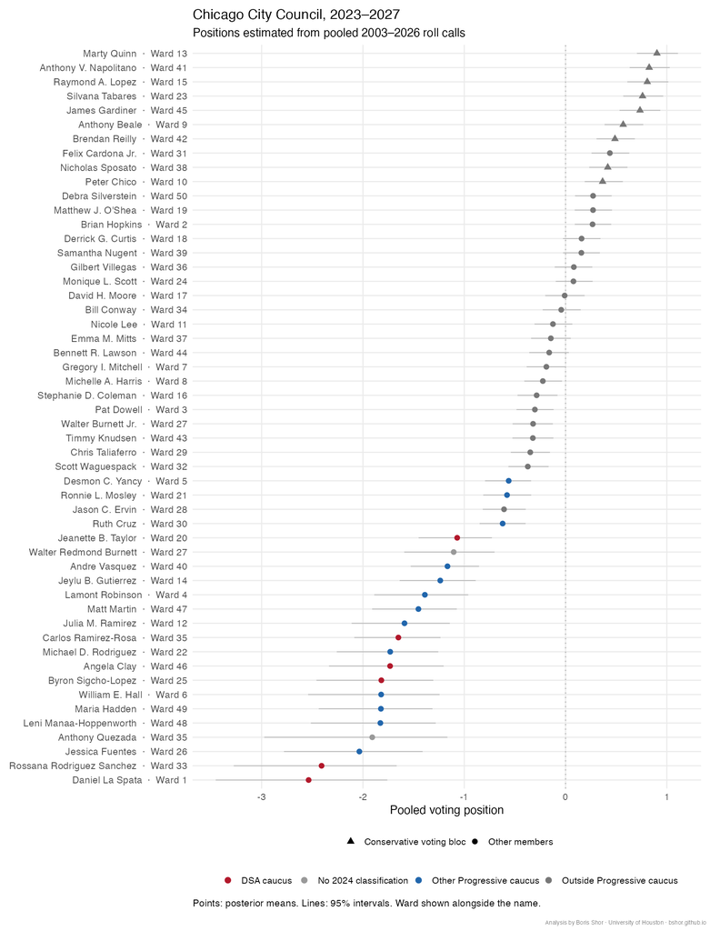

Members observed in the 2023–2027 council term. Colors use the 2024 caucus snapshot; triangles identify its conservative voting bloc.

Daniel La Spata and Rossana Rodríguez-Sánchez sit toward the progressive end. The moderate/conservative bloc occupies a different part of the scale, but its members are not interchangeable. The historical fit also includes earlier members; the recent council should not be read as containing the endpoints of every past council.

## Presidential voting by ward

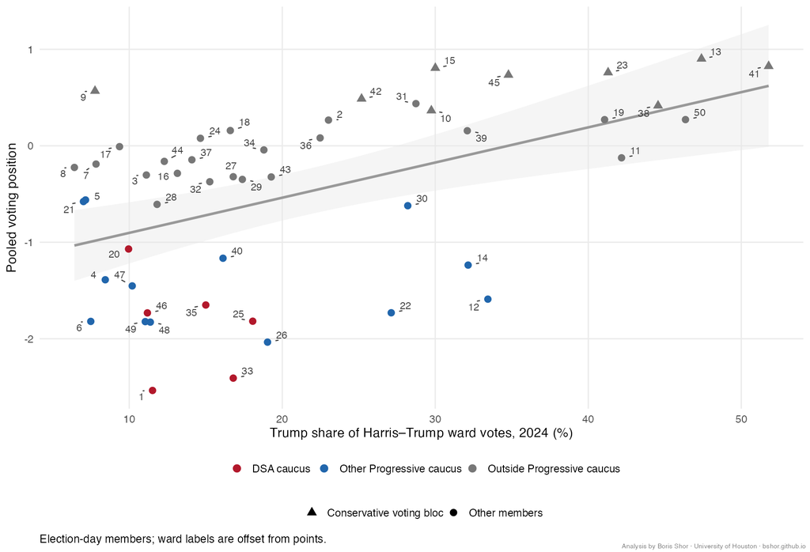

2024 presidential voting and council positions for the fifty election-day members. Ward labels are separated from the points.

Ward presidential voting has the expected relationship with the council scale: Pearson’s correlation is **0.48** across 50 wards (R² = 0.23). This compares constituents’ presidential choices with their representative’s pooled council voting position; it is not a causal model or a claim that presidential politics explains every local coalition.

The comparison uses the *New York Times* 2024 precinct results aggregated to wards, and the members serving on November 5, 2024—not later successors or historical holders of the same wards. The previously checked 1,291 precinct rows and vote totals are retained; only their match to the expanded scores changes. [NYT data documentation](https://github.com/nytimes/presidential-precinct-map-2024); [Chicago certified canvass](https://cboeprod.blob.core.usgovcloudapi.net/prod/2024-11/Proclamation%20of%20Official%20Results%20%28November%205%2C%202024%29.pdf).

## Earlier elected councils

The same pooled positions are shown below for each earlier council. Wide intervals matter, especially for members observed in only the short outgoing 2003 fragment. These are comparisons of council composition, not estimates of individual members moving over time.

**2019–2023**

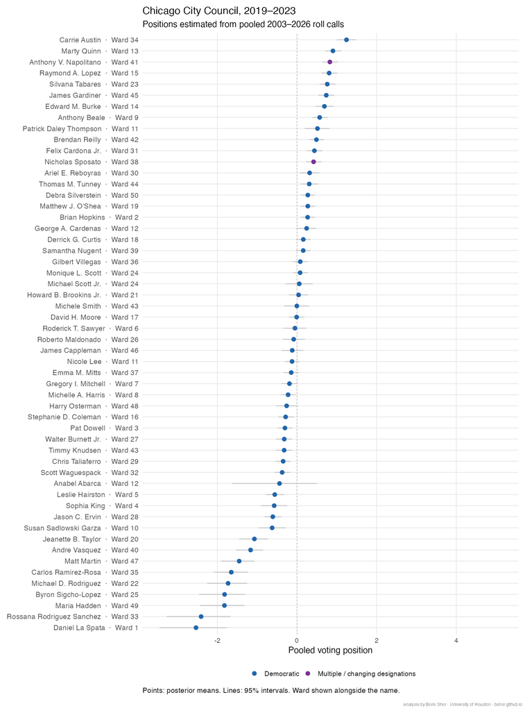

**2015–2019**

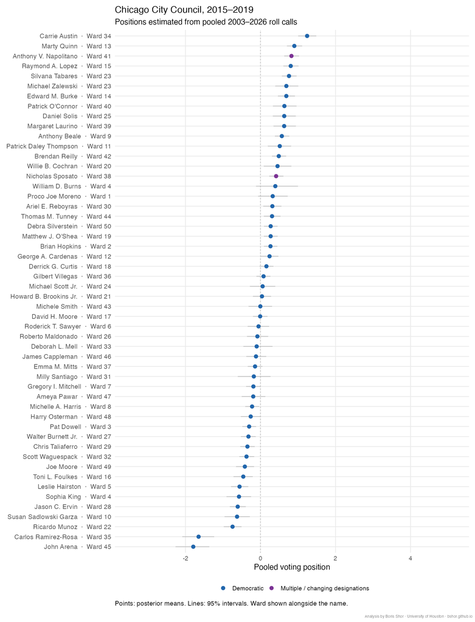

**2011–2015**

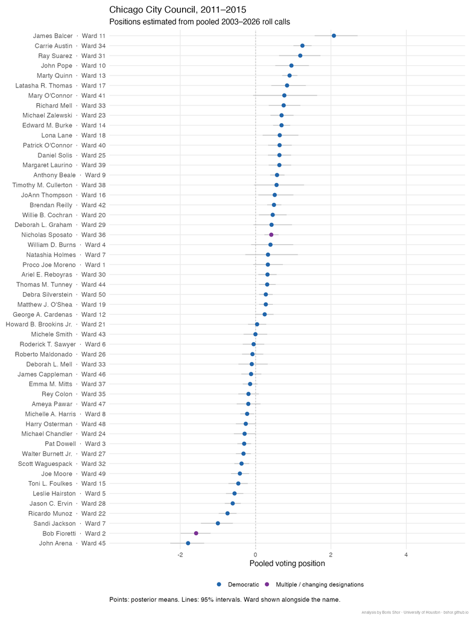

**2007–2011**

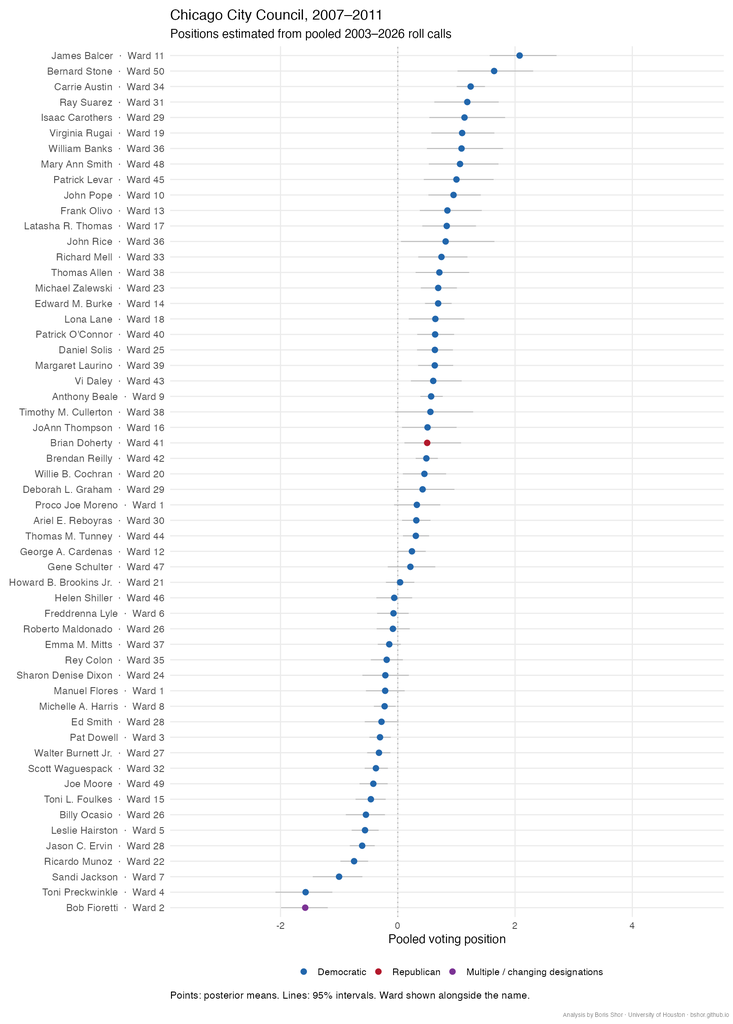

**2003–2007**

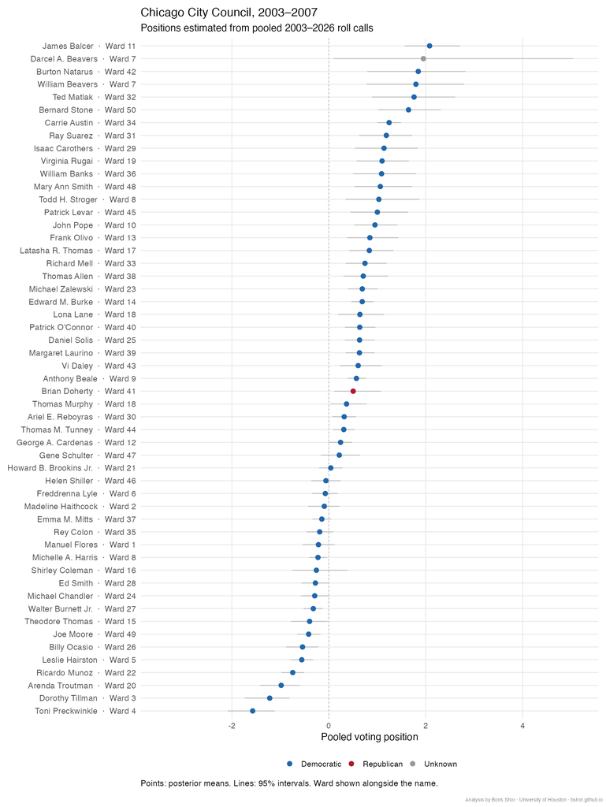

**Outgoing 2003 council**

Only seven contested roll calls fall in this short pre-inauguration fragment. Some members’ estimates borrow information from later service, while those who departed have very limited records. Their wide intervals do not support precise endpoint rankings.

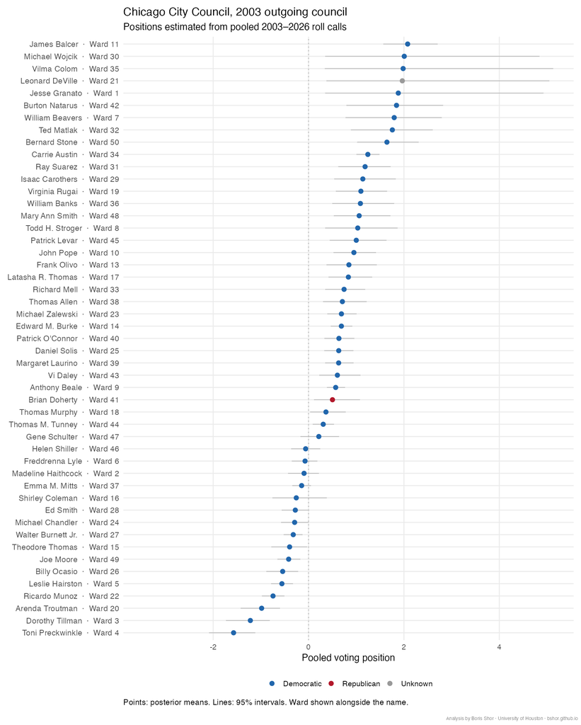

## Caucuses and endorsements

The following memberships are the dated 2024 rosters in Tables 5–10 of UIC’s [first-year Johnson report](https://pols.uic.edu/wp-content/uploads/sites/273/2024/06/Mayor-Brandon-Johnsons-First-Year.pdf). They classify 50 people, not every member who has ever held their wards. Later successors and historical members are not silently assigned a 2024 group.

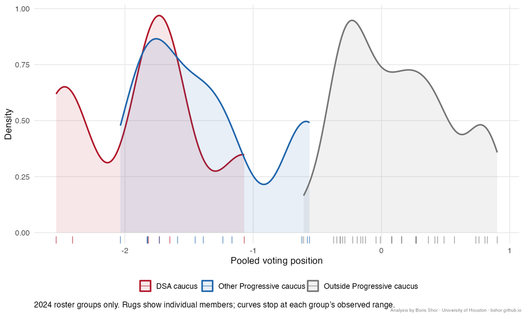

The DSA and other Progressive caucus members cluster toward the negative end. Rugs show individual members; these groups have different sizes.

**Caucus comparisons**

| Group | Listed | Not listed | Median: listed | Median: not listed | Median difference |
| --- | --- | --- | --- | --- | --- |
| DSA caucus | 6 | 44 | -1.78 | -0.18 | -1.60 |
| Progressive Reform caucus | 19 | 31 | -1.65 | 0.08 | -1.73 |
| Conservative voting bloc | 9 | 41 | 0.73 | -0.37 | 1.11 |
| Black caucus | 19 | 31 | -0.32 | -0.12 | -0.20 |
| Latino caucus | 14 | 36 | -1.41 | -0.18 | -1.24 |
| LGBT caucus | 9 | 41 | -1.65 | -0.19 | -1.46 |

Each row compares members listed in that particular roster with those not listed. The groups overlap: “not listed” does not mean outside every caucus. The conservative voting bloc is itself UIC’s voting-based classification, so its match with this scale is descriptive rather than an independent test.

**Within the Progressive caucus**

| Group | Members | Median |
| --- | --- | --- |
| DSA caucus | 6 | -1.78 |
| Other Progressive caucus | 13 | -1.45 |

This comparison includes only the 19 Progressive caucus members: six DSA members and 13 other Progressives. DSA caucus membership is distinct from a campaign endorsement.

**DSA endorsements**

Chicago DSA’s [2027 endorsement announcement](https://chicagodsa.org/2026/08/15/announcing-chicago-dsas-2027-endorsements/) names Angela Clay, Anthony Quezada, Rossana Rodríguez-Sánchez and Byron Sigcho-Lopez. All four appear in the current council portion of the pooled sample.

| Group | Members | Median |
| --- | --- | --- |
| Named in endorsement announcement | 4 | -1.86 |
| Other current-period members | 48 | -0.25 |

The comparison is restricted to the 52 current-period members. Earlier councillors are not coded “not endorsed” simply because they are absent from a 2026 announcement. This is campaign support for a later election, not continuous membership.

## Party affiliations

External research provides party information for **130 of 132 councillors**: **126 Democratic-affiliated, one Republican, and three with multiple or changing designations**. Darcel Beavers and Leonard DeVille remain unresolved. Unknown does not mean Republican or unaffiliated.

The historical Republican is **Brian Doherty**. UIC’s contemporaneous report identifies the 2004 council as 49 Democrats and Doherty as its sole Republican. This common source, matched to the dated roster, avoids treating Chicago’s officially nonpartisan ballot as evidence of no party affiliation. [UIC report, Figure 4 and accompanying text](https://pols.uic.edu/wp-content/uploads/sites/273/2018/10/vr_CouncilReportDec2005-1.pdf).

Anthony Napolitano and Nicholas Sposato have different affiliations or self-descriptions at different dates; their historical Republican or Democratic records should not erase their later independent identification. **Bob Fioretti** documented Democratic committeeperson service overlapping his council years, and later identified as Republican. His later label is not assigned retrospectively to his council service.

| Researched designation | Councillors |
| --- | --- |
| Democratic | 126 |
| Multiple / changing designations | 3 |
| Republican | 1 |
| Unknown | 2 |

The evidence combines party records, self-descriptions and credible reporting. Some affiliations are documented before or after local service, and those timing limits remain explicit. Four initially unresolved cases were name-matching gaps: the party and vote tables already shared the same person ID. The research and source justifications are available in [the supplementary evidence contribution](https://github.com/MyTownRepo/council-votes/pull/34).

With only one Republican-only record, a party density comparison or a conventional two-party polarization trend would be misleading. Chicago’s caucus and endorsement comparisons provide more useful distinctions within its largely Democratic council.

## Members and policy controversies

The recent council’s progressive–moderate divide connects to substantive disagreements, not just party names.

**Marty Quinn and Raymond Lopez** illustrate the moderate/conservative side of recent council politics. Quinn opposed **Bring Chicago Home**, a graduated real-estate transfer tax proposal earmarked for homelessness programs: supporters emphasized housing revenue and redistribution, while opponents questioned revenue assumptions, implementation and effects on real-estate activity. He also pressed to retain **ShotSpotter**: supporters stressed rapid police response, while critics questioned cost, evidentiary yield and public-safety benefits. Lopez pursued a **sanctuary-city referendum**, amid disagreement about migrant shelter costs and the city’s limits on cooperation with federal immigration enforcement. [WBEZ on Bring Chicago Home](https://www.wbez.org/politics/2024/03/18/what-the-bring-chicago-home-referendum-would-do); [Sun-Times on Quinn and ShotSpotter](https://chicago.suntimes.com/city-hall/2024/10/17/mayor-johnson-city-budget-city-council-shotspotter-property-taxes-armory-marty-quinn); [Axios on the sanctuary-city referendum](https://www.axios.com/local/chicago/2023/11/02/sanctuary-city-referendum-vote-delayed).

**Rossana Rodríguez-Sánchez and Carlos Ramirez-Rosa** illustrate the DSA-aligned side. Rodríguez-Sánchez led **Treatment Not Trauma**, seeking expanded public mental-health clinics and non-police crisis response; disagreements concerned cost, staffing, public versus nonprofit provision and police involvement. Ramirez-Rosa advocated **municipalizing ComEd**, proposing public ownership of the electricity distribution system; supporters stressed accountability and clean energy, while critics emphasized acquisition costs, debt and operational risk. [WBEZ on Treatment Not Trauma](https://www.wbez.org/politics/2023/07/25/mayoral-allies-lay-groundwork-for-treatment-not-trauma-mental-health-plan); [WTTW on municipalizing ComEd](https://news.wttw.com/2019/07/03/socialized-electricity-alderman-floats-government-takeover-comed).

These examples explain recognizable policy divisions. They are not claims that the news stories establish every member’s historical position or that small differences between neighboring estimates are reliable rankings.

## Interpretation and limits

The pooled votes distinguish recognizable Chicago coalitions across successive elected councils. Caucus memberships and ward presidential results support the recent progressive–moderate interpretation. Sparse early records and incomplete affiliations warrant care; technical details and diagnostics are in the appendix.